# dns_achados

Rafilx

2022-04-14

## R Markdown

- Executar as seguintes availiações por quarter
  - verificar se o mesmo queryid existe por vários periodos
  - verificar se o mesmo qname aparece por vários periodos
  - olhar as tabelas antes de plotar
  - Olhar o período passado para verificar o surgimento de novos casos de qname / query_id
  - verificar se tirar ou não o ” HAVING qnt_repeat_query_id > 1”
  - quero gráficos de barra
  - group por qname, qtype e queryid para verificar a ocorrência de grupo de ataques

verificar rfc1034,1035 para queryid repetidos

- Busca os dados no banco com o parse do DNS ja realizado, então temos:
  - qname que é o domínio
  - qtype tipo da query
  - query_id ID da transação definido pelo atacante
  - year_period ano e trimestre em que ocorreu o ataque exemplo “20212” o ataque ocorreu no segundo trimestre do 2021

```r
db <- dbConnect(RSQLite::SQLite(), dbname="./dnstor_statistics_dns.sqlite")

data_unfetch <-dbSendQuery(db, "
  SELECT *, CAST(CAST(year AS text) || CAST(period AS text) as integer) as year_period
    FROM DNS_ANALYSIS
        JOIN DNS_ANALYSIS_QUESTION
          ON DNS_ANALYSIS.id = DNS_ANALYSIS_QUESTION.dns_analysis_id
     WHERE QTYPE != 0
")
data <- fetch(data_unfetch)

dns_data_unfetch <- dbSendQuery(db, "
  SELECT count(*) as countGrouped, year, period, CAST(CAST(year AS text) || CAST(period AS text) as integer) as year_period , qname, qtype, SUM(requests_per_attack) as quantity
    FROM DNS_ANALYSIS
    JOIN DNS_ANALYSIS_QUESTION
      ON DNS_ANALYSIS.id = DNS_ANALYSIS_QUESTION.dns_analysis_id
   WHERE QTYPE != 0
GROUP BY year_period, year, period, qname, qtype
ORDER BY quantity DESC;
")
dns_data_fetched <- fetch(dns_data_unfetch)

dbDisconnect(db)
```

- Primeiro separa todos os registros por trimestre

```r
data_split_year_period = data %>%
  group_split(year_period)
```

- Gerando um total de 6 trimestres

```r
N=10

period_query_id = data.frame()
for (i in c(1:length(data_split_year_period))) {
  query_id_frequency = data_split_year_period[[i]] %>%
    count(query_id)

  query_id_frequency['year_period'] = data_split_year_period[[i]]$year_period[1]

  period_query_id = rbind(period_query_id, head(query_id_frequency[order(-query_id_frequency$n),], N) )
}
```

### Os 10 query_id mais utilizados divididos por período e ordenados pela frequência em que apareceram no período

```r
period_query_id %>%
  group_split(year_period)
```

```
## <list_of<
##   tbl_df<
##     query_id   : integer
##     n          : integer
##     year_period: integer
##   >
## >[6]>
## [[1]]
## # A tibble: 10 × 3
##    query_id     n year_period
##       <int> <int>       <int>
##  1    17767  1917       20204
##  2    16049  1060       20204
##  3    56064  1049       20204
##  4    63710   782       20204
##  5    59797   741       20204
##  6    63374   729       20204
##  7    59378   723       20204
##  8    31694   718       20204
##  9    13304   715       20204
## 10    46512   707       20204
##
## [[2]]
## # A tibble: 10 × 3
##    query_id     n year_period
##       <int> <int>       <int>
##  1    17767 67047       20211
##  2    28940   418       20211
##  3    13551   318       20211
##  4    50265   305       20211
##  5    19592   277       20211
##  6    45810   214       20211
##  7    57166   197       20211
##  8    43855   168       20211
##  9    56643   125       20211
## 10    56686   124       20211
##
## [[3]]
## # A tibble: 10 × 3
##    query_id     n year_period
```

[output cut: 41 more lines]

```
##
## [[6]]
## # A tibble: 10 × 3
##    query_id     n year_period
##       <int> <int>       <int>
##  1    26566  5876       20221
##  2    17767   895       20221
##  3    13551   124       20221
##  4        1   120       20221
##  5    64206    63       20221
##  6    28826    41       20221
##  7       27    29       20221
##  8    14602    19       20221
##  9    50293    15       20221
## 10        6    12       20221
```

### Os 10 query_id mais utilizados em cada período ordenados pela frequência em que apareceram levando em consideração todos os períodos

```r
period_query_id %>%
  arrange(desc(n)) %>%
  head(N)
```

```
## # A tibble: 10 × 3
##    query_id     n year_period
##       <int> <int>       <int>
##  1    17767 67047       20211
##  2    26566 29963       20214
##  3    17767  8479       20214
##  4        1  6859       20213
##  5    26566  5876       20221
##  6    17767  5838       20213
##  7    26566  5090       20212
##  8    17767  3748       20212
##  9    17767  1917       20204
## 10    16049  1060       20204
```

### Os query_id que apareceram com maior frequência entre os top 10 em todos os períodos

- Caso o query_id 13213 fosse top 1 em 20204 e top 3 em 20211 e não aparecer em mais nenhum outro período seu “n” seria 2

```r
period_query_id %>%
  count(query_id) %>%
  arrange(desc(n)) %>%
  filter(n > 1)
```

```
## # A tibble: 8 × 2
##   query_id     n
##      <int> <int>
## 1    17767     6
## 2    13551     5
## 3        1     4
## 4       27     3
## 5    26566     3
## 6    50265     3
## 7    28826     2
## 8    45810     2
```

### Dados agrupados por qname, query_id, período e qtype

```r
period_query_id_qname = data.frame()
for (i in c(1:length(data_split_year_period))) {
  query_id_qname_frequency = data_split_year_period[[i]] %>%
    count(qname, qtype, query_id, year_period, sort = TRUE) %>%
    filter(n > 1)

  period_query_id_qname = rbind(period_query_id_qname, head(query_id_qname_frequency, N) )
}
```

### Os 10 query_id, qname, qtype mais utilizados divididos por período e ordenados pela frequência em que apareceram no período

```r
period_query_id_qname %>%
  group_split(year_period)
```

```
## <list_of<
##   tbl_df<
##     qname      : character
##     qtype      : character
##     query_id   : integer
##     year_period: integer
##     n          : integer
##   >
## >[6]>
## [[1]]
## # A tibble: 10 × 5
##    qname    qtype query_id year_period     n
##    <chr>    <chr>    <int>       <int> <int>
##  1 isc.org. ANY      17767       20204  1141
##  2 irs.gov. ANY      16049       20204  1060
##  3 irs.gov. ANY      56064       20204  1049
##  4 irs.gov. ANY      63710       20204   782
##  5 sl.      ANY      17767       20204   764
##  6 irs.gov. ANY      59797       20204   741
##  7 irs.gov. ANY      63374       20204   728
##  8 irs.gov. ANY      59378       20204   721
##  9 irs.gov. ANY      31694       20204   718
## 10 irs.gov. ANY      13304       20204   713
##
## [[2]]
## # A tibble: 10 × 5
##    qname         qtype query_id year_period     n
##    <chr>         <chr>    <int>       <int> <int>
##  1 isc.org.      ANY      17767       20211 56753
##  2 sl.           ANY      17767       20211 10260
##  3 .             ANY      28940       20211   417
##  4 VERSION.BIND. TXT      13551       20211   314
##  5 .             ANY      19592       20211   273
##  6 .             ANY      57166       20211   196
##  7 .             ANY      43855       20211   164
##  8 fe18.ru.      ANY      56643       20211   124
##  9 fe18.ru.      ANY      56686       20211   122
## 10 .             ANY      10000       20211   117
##
## [[3]]
```

[output cut: 43 more lines]

```
##
## [[6]]
## # A tibble: 10 × 5
##    qname                     qtype query_id year_period     n
##    <chr>                     <chr>    <int>       <int> <int>
##  1 peacecorps.gov.           ANY      26566       20221  5876
##  2 sl.                       ANY      17767       20221   841
##  3 VERSION.BIND.             TXT      13551       20221   122
##  4 ip.parrotdns.com.         A        28826       20221    41
##  5 dnsscan.shadowserver.org. A        64206       20221    33
##  6 version.bind.             TXT      64206       20221    30
##  7 pizzaseo.com.             ANY         27       20221    29
##  8 isc.org.                  ANY      17767       20221    24
##  9 pizzaseo.com.             RRSIG        1       20221    21
## 10 clients1.google.com.      A        14602       20221    19
```

### Os query_id que apareceram com maior frequência entre os top 10 em todos os períodos, agrupados por qname e qtype

- Caso o query_id 13213 de qname = “isc.org.” e qtype = “ANY” fosse top 1 em 20204 e top 3 em 20211 e não aparecer em mais nenhum outro período seu “n” seria 2

```r
top_queryid_qname = period_query_id_qname %>%
  count(query_id, qtype, qname) %>%
  arrange(desc(n)) %>%
  filter(n > 1)

top_queryid_qname
```

```
## # A tibble: 7 × 4
##   query_id qtype qname                 n
##      <int> <chr> <chr>             <int>
## 1    17767 ANY   sl.                   6
## 2    13551 TXT   VERSION.BIND.         5
## 3        1 RRSIG pizzaseo.com.         4
## 4       27 ANY   pizzaseo.com.         3
## 5    17767 ANY   isc.org.              3
## 6    26566 ANY   peacecorps.gov.       3
## 7    28826 A     ip.parrotdns.com.     2
```

### Top 10 consultas que receberam a maior quantidade de requisições por períodos

```r
dns_data.year_period.ungrouped <- group_split(dns_data_fetched, year_period)

dns_data.topNconsultas <- head(dns_data.year_period.ungrouped[[1]], N)
dns_data.year_period.ungrouped.len = length(dns_data.year_period.ungrouped)

dns_columns = c('year_period', 'qtype', 'quantity', 'qname')
select(dns_data.topNconsultas, dns_columns)
```

```
## Note: Using an external vector in selections is ambiguous.
## ℹ Use `all_of(dns_columns)` instead of `dns_columns` to silence this message.
## ℹ See <https://tidyselect.r-lib.org/reference/faq-external-vector.html>.
```

```
## # A tibble: 10 × 4
##    year_period qtype quantity qname
##          <int> <chr>    <int> <chr>
##  1       20204 ANY   19005578 peacecorps.gov.
##  2       20204 ANY     816242 lavrov.in.
##  3       20204 ANY     779892 sl.
##  4       20204 ANY     652325 irs.gov.
##  5       20204 ANY     569411 fe18.ru.
##  6       20204 ANY      12296 .
##  7       20204 ANY      10248 isc.org.
##  8       20204 A         8467 20200328132334-cq9bm.ldd.sohu.com.
##  9       20204 RRSIG     6176 jp.
## 10       20204 A         4953 500940734da64dde863b257c9c12c03d.apigw.ap-southea…
```

```r
select(head(dns_data.year_period.ungrouped[[2]], N), dns_columns)
```

```
## # A tibble: 10 × 4
##    year_period qtype quantity qname
##          <int> <chr>    <int> <chr>
##  1       20211 ANY   32698124 peacecorps.gov.
##  2       20211 ANY    3032399 sl.
##  3       20211 ANY    2418859 isc.org.
##  4       20211 ANY     941083 fe18.ru.
##  5       20211 ANY     463904 wzb.eu.
##  6       20211 ANY     132970 .
##  7       20211 A        20998 mirrorlist.centos.org.
##  8       20211 A        10698 hotspot.accesscam.org.
##  9       20211 MX        8014 pwad.gov.ae.
## 10       20211 A         3882 theguardian.webredirect.org.
```

```r
select(head(dns_data.year_period.ungrouped[[3]], N), dns_columns)
```

```
## # A tibble: 10 × 4
##    year_period qtype quantity qname
##          <int> <chr>    <int> <chr>
##  1       20212 ANY   13183512 peacecorps.gov.
##  2       20212 ANY    1337802 sl.
##  3       20212 ANY     534815 irs.gov.
##  4       20212 ANY     220674 isc.org.
##  5       20212 ANY     124579 fe18.ru.
##  6       20212 ANY      90999 .
##  7       20212 MX       21895 dpc.ae.
##  8       20212 ANY      11229 hcc.nl.
##  9       20212 A        10965 dji.gov.ae.
## 10       20212 A         9144 emaratalyoum.com.
```

```r
select(head(dns_data.year_period.ungrouped[[4]], N), dns_columns)
```

```
## # A tibble: 10 × 4
##    year_period qtype quantity qname
##          <int> <chr>    <int> <chr>
##  1       20213 RRSIG   324789 pizzaseo.com.
##  2       20213 ANY     178363 sl.
##  3       20213 ANY     165932 .
##  4       20213 A         5925 www.ac.my.blastodermic-swimmable.info.
##  5       20213 A         5291 tmall.com.
##  6       20213 A         4848 www.ac.my.superability-kooka.info.
##  7       20213 A         4655 2015annualreport.bloomberg.org.
##  8       20213 A         2794 lpnkuearwljpqwbwz.tmall.com.
##  9       20213 MX        1915 rt.com.
## 10       20213 MX        1888 nawahprogram.ae.
```

```r
select(head(dns_data.year_period.ungrouped[[5]], N), dns_columns)
```

```
## # A tibble: 10 × 4
##    year_period qtype quantity qname
##          <int> <chr>    <int> <chr>
##  1       20214 ANY    4844082 peacecorps.gov.
##  2       20214 ANY     620249 sl.
##  3       20214 A        19541 www.ac.my.blastodermic-swimmable.info.
##  4       20214 A        17848 www.ac.my.superability-kooka.info.
##  5       20214 A        13595 www.ndnslab.com.
##  6       20214 ANY      11073 .
##  7       20214 RRSIG     8499 pizzaseo.com.
##  8       20214 MX        6670 nih.gov.
##  9       20214 A         5932 2015annualreport.bloomberg.org.
## 10       20214 MX        4680 nawahprogram.ae.
```

```r
select(head(dns_data.year_period.ungrouped[[6]], N), dns_columns)
```

```
## # A tibble: 10 × 4
##    year_period qtype quantity qname
##          <int> <chr>    <int> <chr>
##  1       20221 ANY    2614699 peacecorps.gov.
##  2       20221 A        21200 admin.asry.net.
##  3       20221 ANY      19737 sl.
##  4       20221 A        18629 www.ndnslab.com.
##  5       20221 A        11635 ftp.ebisb.com.
##  6       20221 MX        7821 bankfab.com.
##  7       20221 A         6091 vpn.qatarsteel.com.qa.
##  8       20221 MX        6025 zayed.org.ae.
##  9       20221 A         5766 moi.gov.kw.
## 10       20221 MX        5077 mopa.ae.
```

```r
for (i in c(2:dns_data.year_period.ungrouped.len)) {
  dns_data.topNconsultas <- rbind(dns_data.topNconsultas, head(dns_data.year_period.ungrouped[[i]], N))
}
```

```r
## ------------ Quantos ataques com cada tipo de qtype foi utilizado, por trimestre ? ------------
#dns_data_fetched

dns_data_fetched.quarter_type_quantity = select(dns_data_fetched, c('year_period', 'qtype', 'quantity'))

dns_data_fetched.sum_attacks_quarterly = dns_data_fetched.quarter_type_quantity %>%
  group_by(qtype, year_period) %>%
  summarise(quantity = sum(quantity))
```

```r
#dns_data_fetched.sum_attacks_quarterly %>%
#  mutate(year_period=as.factor(year_period)) %>%
#  ggplot(aes(x = year_period, y = quantity, color = qtype)) +
#  geom_line()

#ggplot(data = dns_data_fetched.sum_attacks_quarterly, aes(x = year_period, y = quantity)) +
#    geom_line() +
#    facet_wrap(facets = vars(qtype))

#dns_data_fetched.sum_attacks_quarterly %>%
#  filter(qtype != "ANY") %>%
#  ggplot(aes(x = year_period, y = quantity)) +
#    geom_line() +
#   facet_wrap(facets = vars(qtype))

# ------------------------------------------- quantity with percentage



dns_data_fetched.sum_attacks_quarterly.sum_period_quantity = dns_data_fetched.sum_attacks_quarterly %>%
  group_by(year_period) %>%
  summarise(sum_period_quantity = sum(quantity), qtype=qtype, quantity=quantity)
dns_data_fetched.sum_attacks_quarterly.sum_period_quantity['quantity_percentage'] = (dns_data_fetched.sum_attacks_quarterly.sum_period_quantity$quantity * 100) / dns_data_fetched.sum_attacks_quarterly.sum_period_quantity$sum_period_quantity

#dns_data_fetched.sum_attacks_quarterly.sum_period_quantity %>%
#  filter(quantity_percentage > 0.001) %>%
#  filter(quantity_percentage > 0.1) %>%
  #ggplot(aes(x = year_period, y = quantity_percentage)) +
   # geom_line() +
    #facet_wrap(facets = vars(qtype))


#dns_data_fetched.sum_attacks_quarterly.sum_period_quantity %>%
#  filter(qtype != "ANY") %>%
#  ggplot(aes(x = year_period, y = quantity_percentage)) +
#    geom_line() +
#    facet_wrap(facets = vars(qtype))

#dns_data_fetched.sum_attacks_quarterly.sum_period_quantity %>%
  #mutate(year_period=as.factor(year_period)) %>%
#  filter(quantity_percentage > 0.1) %>%
#  ggplot(aes(x = year_period, y = quantity_percentage, color = qtype)) +
#  geom_line()

# ------------------------------------------- filter any

dns_data_fetched.sum_attacks_quarterly.sum_period_quantity.filter_any = dns_data_fetched.sum_attacks_quarterly %>%
  group_by(year_period) %>%
  filter(qtype != "ANY") %>%
  summarise(sum_period_quantity = sum(quantity), qtype=qtype, quantity=quantity)
dns_data_fetched.sum_attacks_quarterly.sum_period_quantity.filter_any['quantity_percentage'] = (dns_data_fetched.sum_attacks_quarterly.sum_period_quantity.filter_any$quantity * 100) / dns_data_fetched.sum_attacks_quarterly.sum_period_quantity.filter_any$sum_period_quantity

#dns_data_fetched.sum_attacks_quarterly.sum_period_quantity.filter_any %>%
#  ggplot(aes(x = year_period, y = quantity_percentage)) +
#    geom_line() +
#    facet_wrap(facets = vars(qtype))
```

- A quantidade de requests em % por trimestre por qtype

```
## geom_path: Each group consists of only one observation. Do you need to adjust
## the group aesthetic?
## geom_path: Each group consists of only one observation. Do you need to adjust
## the group aesthetic?
```

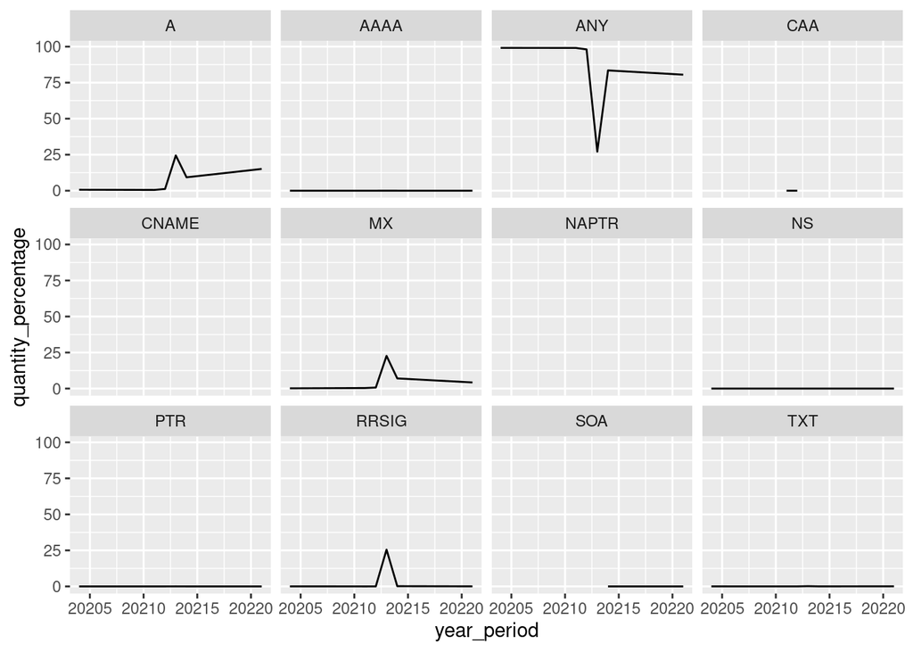

```r
dns_data_fetched.sum_attacks_quarterly.sum_period_quantity %>%
  ggplot(aes(x = year_period, y = quantity_percentage)) +
    geom_line() +
    facet_wrap(facets = vars(qtype))
```

- A quantidade de requests em % por trimestre por qtype
  - lembrando que em 20213 teve um problema em armazenar os dados, por isso talvez essa discrepância

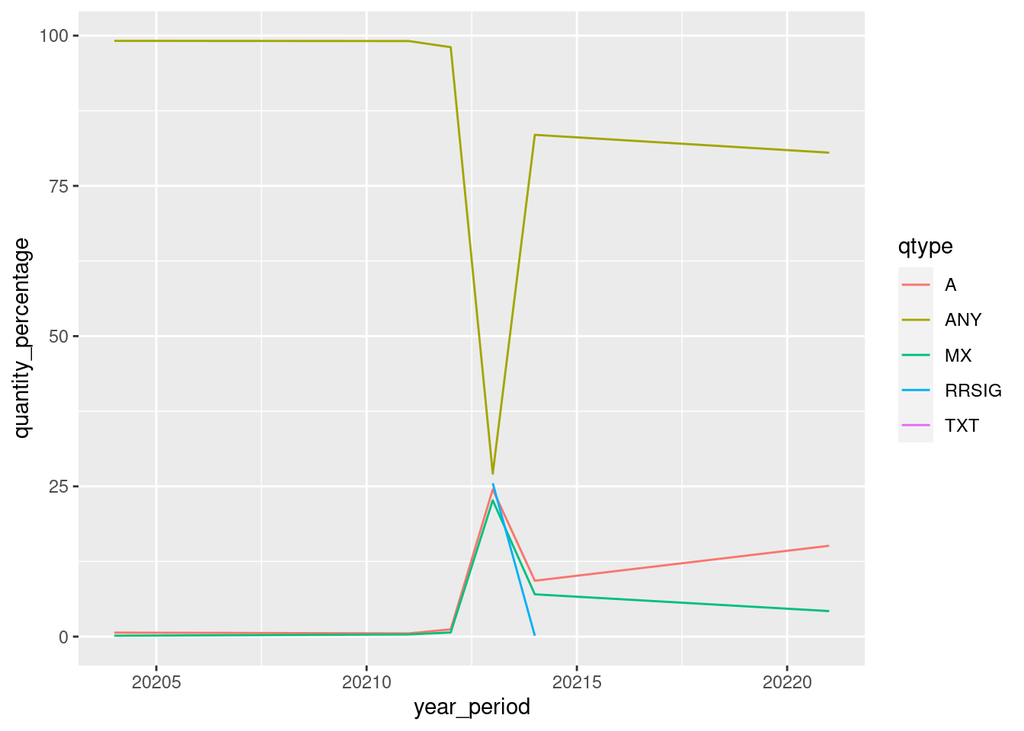

```r
dns_data_fetched.sum_attacks_quarterly.sum_period_quantity %>%
  #mutate(year_period=as.factor(year_period)) %>%
  filter(quantity_percentage > 0.1) %>%
  ggplot(aes(x = year_period, y = quantity_percentage, color = qtype)) +
  geom_line()
```

- Quantos qnames e qtypes novos aparecem em cada trimestre

```r
# ------------ Quantos qtypes novos aprecem em cada trimestre ------------
# > Diferenças percentuais são mais relevantes que absolutas

quarter_qtype_aux = dns_data.year_period.ungrouped[[1]] %>%
  group_by(qtype) %>%
  summarise(quantity = sum(quantity))

#quarter_qtype_2 = dns_data.year_period.ungrouped[[2]] %>%
#  group_by(qtype) %>%
#  summarise(quantity = sum(quantity))

#quarter_qtype_2
#merged = merge(x = quarter_qtype_aux, y = quarter_qtype_2, by = "qtype", all = TRUE)
#merged.new_quantity = merged$quantity.x - merged$quantity.y
#merged

quarter_new_qtype = data.frame()
for (i in c(2:dns_data.year_period.ungrouped.len)) {
  quarter_qtype = dns_data.year_period.ungrouped[[i]] %>%
    group_by(qtype) %>%
    summarise(quantity = sum(quantity))

  merged = merge(x = quarter_qtype_aux, y = quarter_qtype, by = "qtype", all = TRUE)
  merged.new_quantity = merged$quantity.x - merged$quantity.y

  perio_to_period = paste(head(dns_data.year_period.ungrouped[[i - 1]]['year'], 1), '.',  head(dns_data.year_period.ungrouped[[i - 1]]['period'], 1), '->' , head(dns_data.year_period.ungrouped[[i]]['year'], 1), '.', head(dns_data.year_period.ungrouped[[i]]['period'], 1))
  quarter_new_qtype <- rbind(quarter_new_qtype, data.frame(quarter_to_quarter=perio_to_period, merged$qtype, sum_quantity=merged$quantity.y - merged$quantity.x, quantity_percentage=(((merged$quantity.y - merged$quantity.x)*100)/merged$quantity.x), merged$quantity.x, merged$quantity.y))

  quarter_qtype_aux = quarter_qtype
}

#quarter_new_qtype
#head(na.omit(quarter_new_qtype[order(-quarter_new_qtype$quantity_percentage),]))

# ------------ Quantos qname novos aprecem em cada trimestre ------------

quarter_qname_aux = dns_data.year_period.ungrouped[[1]] %>%
  group_by(qname) %>%
  summarise(quantity = sum(quantity))

quarter_new_qname = data.frame()
for (i in c(2:dns_data.year_period.ungrouped.len)) {
  quarter_qname = dns_data.year_period.ungrouped[[i]] %>%
    group_by(qname) %>%
    summarise(quantity = sum(quantity))

  merged = merge(x = quarter_qname_aux, y = quarter_qname, by = "qname", all = TRUE)
  merged.new_quantity = merged$quantity.x - merged$quantity.y

  period_to_period = paste(head(dns_data.year_period.ungrouped[[i - 1]]['year'], 1), '.',  head(dns_data.year_period.ungrouped[[i - 1]]['period'], 1), '->' , ... = head(dns_data.year_period.ungrouped[[i]]['year'], 1), '.', head(dns_data.year_period.ungrouped[[i]]['period'], 1))
  quarter_new_qname <- rbind(quarter_new_qname, data.frame(quarter_to_quarter=period_to_period, merged$qname, sum_quantity=(merged$quantity.y - merged$quantity.x), quantity_percentage_diff=(((merged$quantity.y - merged$quantity.x)*100)/merged$quantity.x), merged$quantity.x, merged$quantity.y))

  quarter_qname_aux = quarter_qname
}
#quarter_new_qname
#head(na.omit(quarter_new_qname[-order(quarter_new_qname$quantity_percentage_diff),]))
```

- Top 10 novos qtypes por trimestre

```r
quarter_new_qtype %>%
  arrange(desc(sum_quantity)) %>%
  select('quarter_to_quarter', 'merged.qtype', 'sum_quantity') %>%
  head(N)
```

```
##      quarter_to_quarter merged.qtype sum_quantity
## 1  2020 . 4 -> 2021 . 1          ANY     17841217
## 2  2021 . 3 -> 2021 . 4          ANY      5133467
## 3  2021 . 2 -> 2021 . 3        RRSIG       325120
## 4  2021 . 3 -> 2021 . 4            A       297381
## 5  2021 . 2 -> 2021 . 3           MX       180707
## 6  2021 . 3 -> 2021 . 4           MX       171803
## 7  2021 . 2 -> 2021 . 3            A       121656
## 8  2020 . 4 -> 2021 . 1           MX       111066
## 9  2020 . 4 -> 2021 . 1            A        67349
## 10 2021 . 4 -> 2022 . 1          TXT          962
```

- Top 10 novos qnames por trimestre

```r
quarter_new_qname %>%
  arrange(desc(sum_quantity)) %>%
  select('quarter_to_quarter', 'merged.qname', 'sum_quantity') %>%
  head(N)
```

```
##      quarter_to_quarter    merged.qname sum_quantity
## 1  2020 . 4 -> 2021 . 1 peacecorps.gov.     13689398
## 2  2021 . 3 -> 2021 . 4 peacecorps.gov.      4844048
## 3  2020 . 4 -> 2021 . 1        isc.org.      2408612
## 4  2020 . 4 -> 2021 . 1             sl.      2252507
## 5  2021 . 1 -> 2021 . 2        irs.gov.       534808
## 6  2021 . 3 -> 2021 . 4             sl.       441886
## 7  2020 . 4 -> 2021 . 1        fe18.ru.       371672
## 8  2021 . 2 -> 2021 . 3   pizzaseo.com.       323981
## 9  2020 . 4 -> 2021 . 1               .       120727
## 10 2021 . 2 -> 2021 . 3               .        76494
```

- Gráfico de barras da porcentagem de qtypes por trimestre

```r
dns_data_fetched.sum_attacks_quarterly.sum_period = dns_data_fetched.sum_attacks_quarterly %>%
  group_by(year_period) %>%
  summarise(period_quantity = sum(quantity), qtype=qtype, quantity=quantity)
dns_data_fetched.sum_attacks_quarterly.sum_period['quantity_percentage'] = (dns_data_fetched.sum_attacks_quarterly.sum_period$quantity * 100) / dns_data_fetched.sum_attacks_quarterly.sum_period$period_quantity
```

- A porcentagem calculada pela quantidade de requisições em cada período por cada qtype

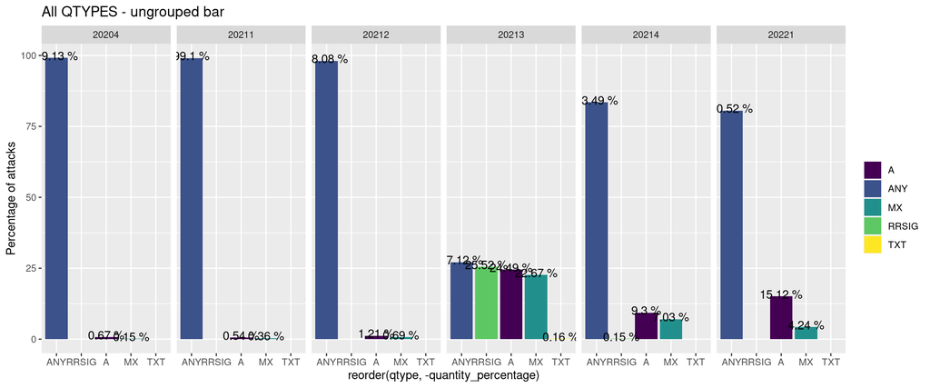

```r
dns_data_fetched.sum_attacks_quarterly.sum_period %>%
  mutate(year_period=as.factor(year_period)) %>%
  filter(quantity_percentage > 0.1) %>%
  ggplot( aes(x=reorder(qtype, -quantity_percentage), y=quantity_percentage, fill=qtype)) +
    geom_bar(stat="identity", position="dodge") +
    scale_fill_viridis(discrete=TRUE, name="") +
    geom_text(aes(label = paste(round(quantity_percentage, 2), "%")), vjust = +0.25, ) +
    facet_grid(~year_period) +
    ylab("Percentage of attacks") +
    ggtitle("All QTYPES - ungrouped bar")
```

- Novamente a porcentagem calculada pela quantidade de requisições em cada período por cada qtype, cada barra é um trimestre

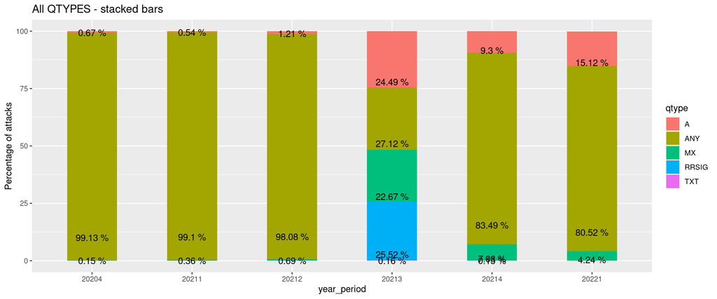

```r
dns_data_fetched.sum_attacks_quarterly.sum_period %>%
  mutate(year_period=as.factor(year_period)) %>%
  filter(quantity_percentage > 0.1) %>%
  ggplot( aes(x=year_period, y=quantity_percentage, fill=qtype)) +
    geom_bar(stat="identity", width = 0.5) +
    geom_text(aes(label = paste(round(quantity_percentage, 2), "%")), position = position_stack(vjust = 0.1)) +
    #scale_fill_viridis(discrete=TRUE, name="") +
    ylab("Percentage of attacks") +
    ggtitle("All QTYPES - stacked bars")
```

- Porcentagem da quantidade de requisições por trimestre por qtype em que tenha no mínimo 1% de requisições totais realizadas

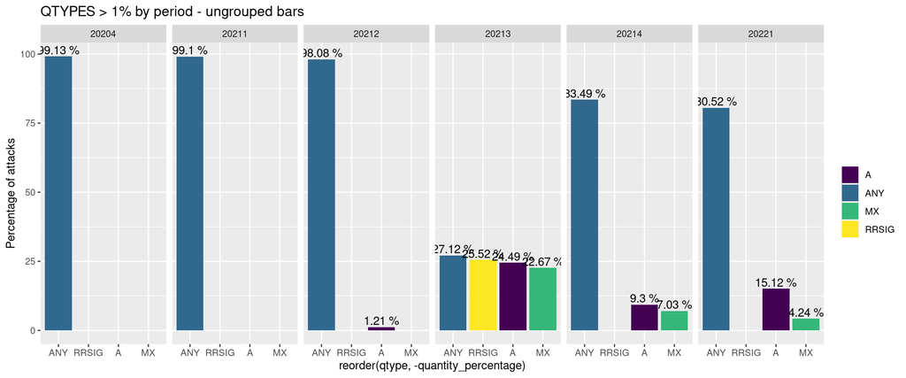

```r
## Filter data using qtype quantity percentage bigger than 1

dns_data_fetched.sum_attacks_quarterly.sum_period %>%
  filter(quantity_percentage > 1) %>%
  mutate(year_period=as.factor(year_period)) %>%
  ggplot( aes(x=reorder(qtype, -quantity_percentage), y=quantity_percentage, fill=qtype)) +
    geom_bar(stat="identity", position="dodge") +
    geom_text(aes(label = paste(round(quantity_percentage, 2), "%")), vjust = -0.25) +
    facet_grid(~year_period) +
    scale_fill_viridis(discrete=TRUE, name="") +
    ylab("Percentage of attacks") +
    ggtitle("QTYPES > 1% by period - ungrouped bars")
```

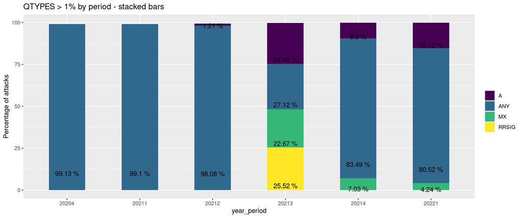

```r
dns_data_fetched.sum_attacks_quarterly.sum_period %>%
  filter(quantity_percentage > 1) %>%
  mutate(year_period=as.factor(year_period)) %>%
  ggplot( aes(x=year_period, y=quantity_percentage, fill=qtype)) +
    geom_bar(stat="identity", width = 0.5) +
    geom_text(aes(label = paste(round(quantity_percentage, 2), "%")), position = position_stack(vjust = 0.1)) +
    scale_fill_viridis(discrete=TRUE, name="") +
    ylab("Percentage of attacks") +
    ggtitle("QTYPES > 1% by period - stacked bars")
```

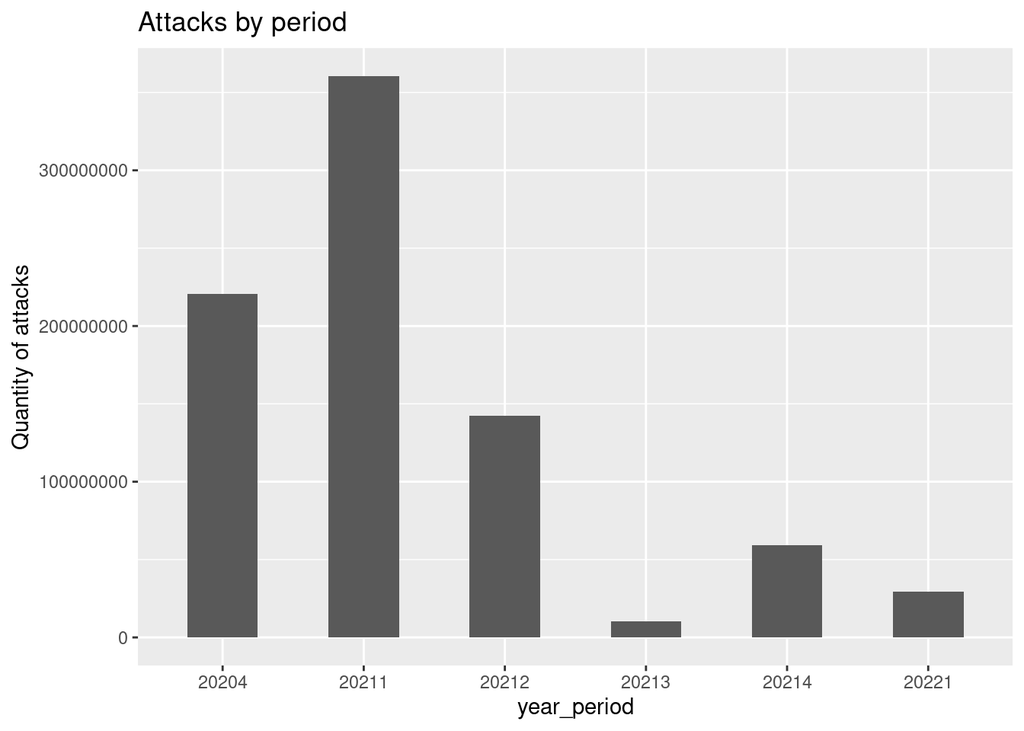

```r
dns_data_fetched.sum_attacks_quarterly.sum_period %>%
  mutate(year_period=as.factor(year_period)) %>%
  ggplot( aes(x=year_period, y=period_quantity)) +
    geom_bar(stat="identity", width = 0.5) +
    scale_fill_viridis(discrete=TRUE, name="") +
    ylab("Quantity of attacks") +
    ggtitle("Attacks by period")
```